# Data Science in Python

#### Christine Lee | December 13, 2017 | Frederick Community College

## Introduction

- Started to learn programming with BASIC in high school
- Using Python and studying machine learning since 2015
- Analyst with Guitar Center, Inc
  - Retail manager > Procurement agent > ERP support > Shared service analyst

```python
from IPython.display import Image
import warnings
warnings.filterwarnings('ignore')
```

# What is Data Science?

[figure not shown]

## Definition

Wikipedia defines as:

> "Data science, also known as data-driven science, is an interdisciplinary field about scientific methods, processes, and systems to extract knowledge or insights from data in various forms, either structured or unstructured, similar to data mining."

## Data Scientist

*Domain Knowledge*

- Domain knowledge
- Expert knoweldge in your field

*Mathematics*

- Statistics
- Linear Algebra
- Calculus
- Mathematics preferred in domain

*Computer Science*

- Data structures
- Networks
- Distributed computing
- Progamming language(s)

# Python Distributions

[figure not shown]

## Anaconda Python is the best data science Python distribution

# Data Science Packages

[figure not shown]

### NumPy is the core scientific computing package for nearly every data science library in the ecosystem.

- Tuned for performance - CPython under the hood
- Uses a N-dimensional array object - NumPy Array
- Linear alegbra, Fourier transform, random number functions

```python
import numpy as np    #np is the most common alias
```

```python
for i in range(5):
    print(np.random.randint(0,100))
```

```
48
27
0
45
42
```

```python
np.array([[0,1,3],[3,2,1]])
```

```
array([[0, 1, 3],
       [3, 2, 1]])
```

```python
X = np.array([[1,2],[4,5]])
print(X)
```

```
[[1 2]
 [4 5]]
```

```python
y = np.array([[2,1],[3,6]])
print(y)
```

```
[[2 1]
 [3 6]]
```

```python
X * y
```

```
array([[ 2,  2],
       [12, 30]])
```

```python
print('np.dot(X, y): ','\n', np.dot(X, y),'\n')
print('X @ y: ','\n', X @ y)
```

```
np.dot(X, y):
 [[ 8 13]
 [23 34]]

X @ y:
 [[ 8 13]
 [23 34]]
```

```python
y_hat = np.array([[1,2,3],[4,5,6],[7,8,9]])
print(y_hat)
```

```
[[1 2 3]
 [4 5 6]
 [7 8 9]]
```

```python
print(y_hat.transpose())
```

```
[[1 4 7]
 [2 5 8]
 [3 6 9]]
```

[figure not shown]

## SymPy is a symbolic mathematics library for Python

```python
from sympy import *
import math
```

```python
print('Python Math library: ',math.sqrt(8))
print('SymPy Library: ', sympy.sqrt(8))
```

```
Python Math library:  2.8284271247461903
SymPy Library:  2*sqrt(2)
```

```python
x, t, z, nu = symbols('x t z nu')
```

```python
init_printing(use_unicode=True)
diff(sin(x)*exp(x), x)
```

$$e^{x} \sin{\left (x \right )} + e^{x} \cos{\left (x \right )}$$

```python
integrate(exp(x)*sin(x) + exp(x)*cos(x), x)
```

$$e^{x} \sin{\left (x \right )}$$

## SymPy Applications

- Symbolic statistical modeling
- Quantumn computing with Python
  - **Cadabra**: Tensor algebra and (quantum) field theory system using SymPy for scalar algebra.
  - **Quameon**: Quantum Monte Carlo in Python.
  - **Quantum Programming in Python**: Quantum 1D Simple Harmonic Oscillator and Quantum Mapping Gate.

[figure not shown]

### SciPy builds on top of NumPy and offers many scientific and engineering libraries

SciPy has many libraries to perform various scientific and engineering.

### SciPy.spatial | Delaunay triangulation

```python
from scipy.spatial import Delaunay
import numpy as np
points = np.array([[0, 0], [0, 1.1], [1, 0], [1, 1]])
tri = Delaunay(points)
```

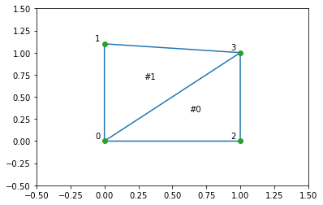

```python
%matplotlib inline
import matplotlib.pyplot as plt
plt.triplot(points[:,0], points[:,1], tri.simplices)
plt.plot(points[:,0], points[:,1], 'o')
for j, p in enumerate(points):
    plt.text(p[0]-0.03, p[1]+0.03, j, ha='right') # label the points
for j, s in enumerate(tri.simplices):
    p = points[s].mean(axis=0)
    plt.text(p[0], p[1], '#%d' % j, ha='center') # label triangles
plt.xlim(-0.5, 1.5); plt.ylim(-0.5, 1.5)
plt.show()
```

### SciPy.Optimize | Minimizing the Rosenbrock function

$f(x) = \sum_{i=1}^{N-1} 100(x_i - x_{i-1}^2)^2 + (1 - x_{i-1})^2$

```python
import numpy as np
from scipy.optimize import minimize

def rosen(x):
    """The Rosenbrock function"""
    return sum(100.0*(x[1:]-x[:-1]**2.0)**2.0 + (1-x[:-1])**2.0)

x0 = np.array([1.3, 0.7, 0.8, 1.9, 1.2])
res = minimize(fun=rosen, x0=x0, method='nelder-mead',
               options={'xtol': 1e-8, 'disp': True})
print(res.x)
```

```
Optimization terminated successfully.
         Current function value: 0.000000
         Iterations: 339
         Function evaluations: 571
[ 1.  1.  1.  1.  1.]
```

[figure not shown]

### SciKit Learn is a machine learning library built on top of NumPy and SciPy

SciKit learn, or sklearn for short, contains many functions and machine learning algorithms. Everything from a method to separate data into testing and training datasets, to methods to cross validate parameter tuning, and scoring methods to grade results against labeled data or specific cost functions.

- Classification Algorithms
  - K-Neighbors
  - Naive Bayes
- Regression Algorithms
  - Linear regression
  - Logisitic regression
- Clustering Algorithms
  - K-Means
- Neural networks / Perceptrons
- Support Vector Machines

```python
from sklearn.tree import DecisionTreeClassifier, DecisionTreeRegressor
```

[figure not shown]

### Pandas is a library built for data manipulation and analysis.

```python
import pandas as pd
```

[figure not shown]

### Matplotlib is a visulization and plotting library for Python

```python
%matplotlib inline
```

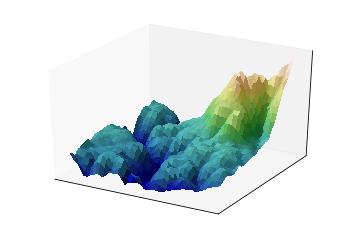

```python
from mpl_toolkits.mplot3d import Axes3D
from matplotlib import cbook
from matplotlib import cm
from matplotlib.colors import LightSource
import matplotlib.pyplot as plt
import numpy as np

filename = cbook.get_sample_data('jacksboro_fault_dem.npz', asfileobj=False)
with np.load(filename) as dem:
    z = dem['elevation']
    nrows, ncols = z.shape
    x = np.linspace(dem['xmin'], dem['xmax'], ncols)
    y = np.linspace(dem['ymin'], dem['ymax'], nrows)
    x, y = np.meshgrid(x, y)

region = np.s_[5:50, 5:50]
x, y, z = x[region], y[region], z[region]

fig, ax = plt.subplots(subplot_kw=dict(projection='3d'))

ls = LightSource(270, 45)
# To use a custom hillshading mode, override the built-in shading and pass
# in the rgb colors of the shaded surface calculated from "shade".
rgb = ls.shade(z, cmap=cm.gist_earth, vert_exag=0.1, blend_mode='soft')
surf = ax.plot_surface(x, y, z, rstride=1, cstride=1, facecolors=rgb,
                       linewidth=0, antialiased=False, shade=False)
ax.set_xticks([])
ax.set_yticks([])
ax.set_zticks([])
fig.savefig("surface3d_frontpage.png", dpi=25)  # results in 160x120 px image
```

# Seaborn

[figure not shown]

### Seaborn builds on top of Matplotlib for more beautiful plots

### Scatterplot Matrix

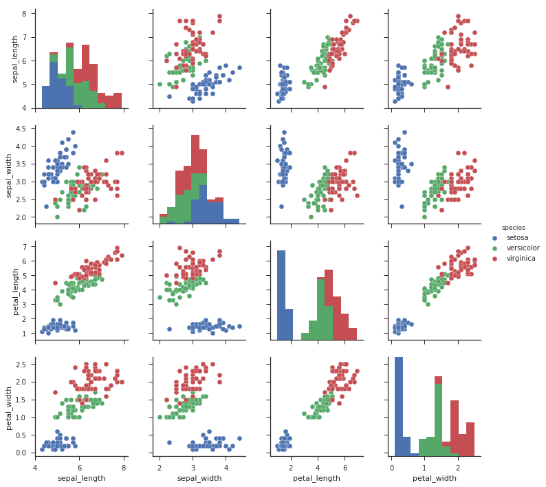

```python
import seaborn as sns
sns.set(style="ticks")

df = sns.load_dataset("iris")
sns.pairplot(df, hue="species")
```

### Faceted logistic regression

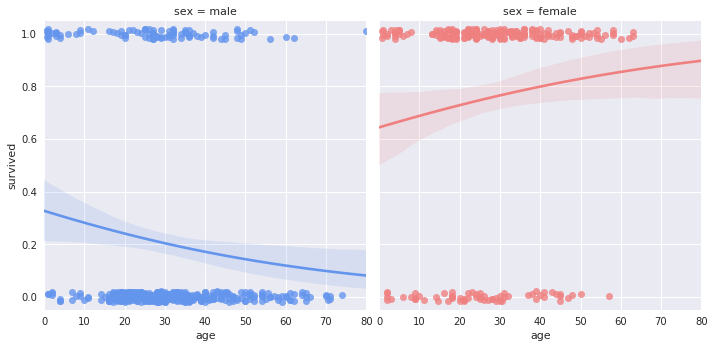

```python
import seaborn as sns
sns.set(style="darkgrid")

# Load the example titanic dataset
df = sns.load_dataset("titanic")

# Make a custom palette with gendered colors
pal = dict(male="#6495ED", female="#F08080")

# Show the survival proability as a function of age and sex
g = sns.lmplot(x="age", y="survived", col="sex", hue="sex", data=df,
               palette=pal, y_jitter=.02, logistic=True)
g.set(xlim=(0, 80), ylim=(-.05, 1.05))
```

### Violin Plots

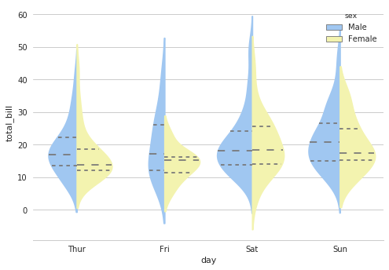

```python
import seaborn as sns
sns.set(style="whitegrid", palette="pastel", color_codes=True)

# Load the example tips dataset
tips = sns.load_dataset("tips")

# Draw a nested violinplot and split the violins for easier comparison
sns.violinplot(x="day", y="total_bill", hue="sex", data=tips, split=True,
               inner="quart", palette={"Male": "b", "Female": "y"})
sns.despine(left=True)
```

| Bokeh | Plotly |
| --- | --- |

### Bokeh and Plotly take visulization to the next level by making it interactive

## Bokeh

```python
# from bokeh.io import show
from bokeh.models import (
    ColumnDataSource,
    HoverTool,
    LogColorMapper
)
from bokeh.palettes import Viridis6 as palette
from bokeh.plotting import figure

from bokeh.sampledata.us_counties import data as counties
from bokeh.sampledata.unemployment import data as unemployment

palette.reverse()

counties = {
    code: county for code, county in counties.items() if county["state"] == "tx"
}

county_xs = [county["lons"] for county in counties.values()]
county_ys = [county["lats"] for county in counties.values()]

county_names = [county['name'] for county in counties.values()]
county_rates = [unemployment[county_id] for county_id in counties]
color_mapper = LogColorMapper(palette=palette)

source = ColumnDataSource(data=dict(
    x=county_xs,
    y=county_ys,
    name=county_names,
    rate=county_rates,
))

TOOLS = "pan,wheel_zoom,reset,hover,save"

p = figure(
    title="Texas Unemployment, 2009", tools=TOOLS,
    x_axis_location=None, y_axis_location=None
)
p.grid.grid_line_color = None

p.patches('x', 'y', source=source,
          fill_color={'field': 'rate', 'transform': color_mapper},
          fill_alpha=0.7, line_color="white", line_width=0.5)

hover = p.select_one(HoverTool)
hover.point_policy = "follow_mouse"
hover.tooltips = [
    ("Name", "@name"),
    ("Unemployment rate)", "@rate%"),
    ("(Long, Lat)", "($x, $y)"),
]

show(p)
```

http://bokeh.pydata.org/en/latest/docs/gallery/texas.html

[figure not shown]

## Plotly

```python
#Import Dependencies
import pandas as pd
import numpy as np
%matplotlib inline
from plotly import __version__
from plotly.offline import download_plotlyjs, init_notebook_mode, plot, iplot
import cufflinks as cf

init_notebook_mode(connected=True)
cf.go_offline()

#Generate fake data
df = pd.DataFrame(np.random.randn(100,4),columns='A B C D'.split())
df2 = pd.DataFrame({'Category':['A','B','C'],'Values':[32,43,50]})
df.head()
```

[output not shown]

|  | A | B | C | D |
| --- | --- | --- | --- | --- |
| 0 | -0.113736 | -0.586661 | -0.631576 | -0.987412 |
| 1 | 0.101812 | 0.714758 | 0.988526 | -0.830557 |
| 2 | -3.148195 | 0.341249 | -0.133508 | 0.516975 |
| 3 | -0.071596 | 0.787874 | -0.968103 | 2.624950 |
| 4 | -0.235104 | -0.536323 | 0.566832 | -0.223215 |

```python
df2.head()
```

|  | Category | Values |
| --- | --- | --- |
| 0 | A | 32 |
| 1 | B | 43 |
| 2 | C | 50 |

### Scatter Plot

```python
df.iplot(kind='scatter',x='A',y='B',mode='markers',size=10)
```

[interactive chart not shown]

### Bar Plot

```python
df2.iplot(kind='bar',x='Category',y='Values')
```

[interactive chart not shown]

### Box and Whiskers Plot

```python
df.iplot(kind='box')
```

[interactive chart not shown]

### 3D Surface

```python
df3 = pd.DataFrame({'x':[1,2,3,4,5],'y':[10,20,30,20,10],'z':[5,4,3,2,1]})
df3.iplot(kind='surface',colorscale='rdylbu')
```

[interactive chart not shown]

# Jupyter Notebooks

[figure not shown]

## Jupyter Notebooks has been making this presentation possible

### LaTeX support:

- $fmax(x) = 1 - cosine(A - B) $
- $fmin(x) = cosine(A - B)$
- $len(X_{ans}) = len(X_{init}) $
- $X_{ans}^{i} \leq X_{init}^{i}$
- $f(\theta) = \frac{1}{m} \sum_{i=1}^m$

### Multi-langauge IDE

Currently supports nearly 100 different kernals

```python
import pandas as pd
df = pd.read_html("https://github.com/jupyter/jupyter/wiki/Jupyter-kernels")
df[0]
```

|  | Name | Jupyter/IPython Version | Language(s) Version | 3rd party dependencies | Example Notebooks | Notes |
| --- | --- | --- | --- | --- | --- | --- |
| 0 | Coarray-Fortran | Jupyter 4.0 | Fortran 2008/2015 | GFortran >= 7.1, OpenCoarrays, MPICH >= 3.2 | Demo, Binder demo | Docker image |
| 1 | sparkmagic | Jupyter >=4.0 | Pyspark (Python 2 & 3), Spark (Scala), SparkR (R) | Livy | Notebooks, Docker Images | This kernels are implemented via the magics ma... |
| 2 | sas_kernel | Jupyter 4.0 | python >= 3.3 | SAS 9.4 or higher | NaN | NaN |
| 3 | IPyKernel | Jupyter 4.0 | python 2.7, >= 3.3 | pyzmq | NaN | NaN |
| 4 | IJulia | NaN | julia >= 0.3 | NaN | NaN | NaN |
| 5 | IHaskell | NaN | ghc >= 7.6 | NaN | NaN | NaN |
| 6 | IRuby | NaN | ruby >= 2.1 | NaN | NaN | NaN |
| 7 | IJavascript | NaN | nodejs >= 0.10 | NaN | NaN | NaN |
| 8 | jpCoffeescript | NaN | coffeescript >= 1.7 | NaN | NaN | NaN |
| 9 | ICSharp | Jupyter 4.0 | C# 4.0+ | scriptcs | NaN | NaN |
| 10 | IRKernel | IPython 3.0 | R 3.2 | rzmq | NaN | NaN |
| 11 | SageMath | Jupyter 4 | Any | many | NaN | NaN |
| 12 | pari_jupyter | Jupyter 4 | 2.8 | Cython | NaN | NaN |
| 13 | IFSharp | IPython 2.0 | F# | NaN | Features | NaN |
| 14 | lgo | Jupyter >= 4, JupyterLab | Go >= 1.8 | ZeroMQ (4.x) | Example | Docker image |
| 15 | gopherlab | Jupyter 4.1, JupyterLab | Go >= 1.6 | ZeroMQ (4.x) | examples | NaN |
| 16 | Gophernotes | Jupyter 4 | Go >= 1.4 | zeromq 2.2.x | examples | docker image |
| 17 | IGo | NaN | Go >= 1.4 | NaN | NaN | NaN |
| 18 | IScala | NaN | Scala | NaN | NaN | NaN |
| 19 | Jupyter-scala | IPython>=3.0 | Scala>=2.10 | NaN | example | NaN |
| 20 | IErlang | IPython 2.3 | Erlang | rebar | NaN | NaN |
| 21 | ITorch | IPython >= 2.2 | Torch 7 (LuaJIT) | NaN | NaN | NaN |
| 22 | IElixir | Jupyter < 6.0 | Elixir < 1.5 | Erlang OTP <= 19.3, Rebar | example | IElixir Notebook in Docker |
| 23 | ierl | Jupyter >= 4.0 | Erlang 19 or 20, Elixir 1.4 or 1.5, LFE 1.2 | Erlang, (optional) Elixir | NaN | NaN |
| 24 | IAldor | IPython >= 1 | Aldor | NaN | NaN | NaN |
| 25 | IOCaml | IPython >= 1.1 | OCaml >= 4.01 | opam | NaN | NaN |
| 26 | OCaml-Jupyter | Jupyter >= 4.0 | OCaml >= 4.02 | opam | Example | Docker image |
| 27 | IForth | IPython >= 3 | Forth | NaN | NaN | NaN |
| 28 | IPerl | NaN | Perl 5 | NaN | NaN | NaN |
| 29 | Perl6 | Jupyter >= 4 | Perl 6.d | zeromq 4 | NaN | NaN |
| ... | ... | ... | ... | ... | ... | ... |
| 68 | Prolog | NaN | Prolog | NaN | NaN | MetaKernel |
| 69 | cl-jupyter | Jupyter | Common Lisp | Quicklisp | About | NaN |
| 70 | Maxima-Jupyter | Jupyter | Maxima | Quicklisp | NaN | NaN |
| 71 | Calysto LC3 | NaN | NaN | NaN | NaN | Assembly Language for the Little Computer 3 |
| 72 | Yacas | NaN | YACAS | NaN | NaN | NaN |
| 73 | IJython | NaN | Jython 2.7 | NaN | NaN | NaN |
| 74 | ROOT | Jupyter | C++/python | ROOT >= 6.05 | NaN | NaN |
| 75 | Gnuplot Kernel | NaN | Gnuplot | NaN | Example | MetaKernel |
| 76 | Tcl | Jupyter | Tcl 8.5 | NaN | NaN | Based on Bash Kernel |
| 77 | J | Jupyter | J 805 | NaN | Examples | NaN |
| 78 | Jython | Jupyter>=4.0 | Jython>=2.7.0 | Java>=7 | NaN | Java based JSR223 compliant |
| 79 | C | Jupyter | C | gcc | NaN | NaN |
| 80 | TaQL | Jupyter | TaQL | python-casacore | TaQL tutorial | NaN |
| 81 | Coconut | Jupyter | Coconut | NaN | NaN | NaN |
| 82 | SPARQL | Jupyter 4 | Python 2.7 or >=3.4 | rdflib, SPARQLWrapper | Examples | Optional GraphViz dependency |
| 83 | AIML chatbot | Jupyter 4 | Python 2.7 | pyAIML | Examples | NaN |
| 84 | IArm | Jupyter 4 | ARMv6 THUMB | NaN | Examples | Based off of the ARM Cortex M0+ CPU |
| 85 | SoS | Jupyter 4 | Python >=3.4 | NaN | Examples | Workflow system, Multi-Kernel support |
| 86 | jupyter-nodejs | Jupyter, iPython 3.x | NodeJS, Babel, Clojurescript | NaN | Examples | NaN |
| 87 | Pike | IPython >= 3 | Pike >= 7.8 | NaN | NaN | Wrapper, Based on Bash Kernel |
| 88 | ITypeScript | NaN | Typescript >= 2.0 | Node.js >= 0.10.0 | NaN | NaN |
| 89 | imatlab | ipykernel >= 4.1 | MATLAB >= 2016b | NaN | NaN | NaN |
| 90 | jupyter-kotlin | Jupyter | Kotlin 1.1-M04 EAP | Java >= 8 | NaN | NaN |
| 91 | jupyter_kernel_singular | Jupyter | Singular 4.1.0 | NaN | Demo | Optional PySingular for better performance, su... |
| 92 | spylon-kernel | ipykernel >=4.5 | python >= 3.5, scala >= 2.11 | Apache Spark >=2.0 | Example | MetaKernel |
| 93 | mit-scheme-kernel | Jupyter 4.0 | MIT Scheme 9.2 | NaN | NaN | NaN |
| 94 | elm-kernel | Jupyter | NaN | NaN | Examples | NaN |
| 95 | SciJava Jupyter Kernel | Jupyter 4.3.0 | Java + 9 scripting languages | Java | Examples | NaN |
| 96 | Isbt | Jupyter 4.3.0 | sbt >= 1.0.0 | sbt | example | NaN |
| 97 | BeakerX | NaN | NaN | Groovy, Java, Scala, Clojure, Kotlin, SQL | example | docker image |

98 rows × 6 columns

## Shareable

- IPython interpreters
- .py files
- HTML documents
- PDFs

# Resources

## Documentation

### **Anaconda**: https://www.anaconda.com/what-is-anaconda/

### Data Science Libraries

- **PyData**: https://pydata.org/
- **SciPy**: https://www.scipy.org/
  - IPython: http://ipython.org/
  - NumPy: http://www.numpy.org/
  - Pandas: http://pandas.pydata.org/
  - SciKit-Learn: http://scikit-learn.org/stable/
  - SciPy: https://www.scipy.org/scipylib/index.html
  - SymPy: http://www.sympy.org/en/index.html

### Visualization Libraries

- **Bokeh**: http://bokeh.pydata.org/en/latest/
- **Matplotlib**: http://matplotlib.org/
- **Plotly**: https://plot.ly/python/
- **Seaborn**: https://seaborn.pydata.org/

### **Jupyter**: http://jupyter.org/

### **LaTeX**: https://www.latex-project.org/

## Educational Resources

### Massive Open Online Courses (MOOCs)

- **Coursera**: https://www.coursera.org/
- **DataCamp**: https://www.datacamp.com/
- **edX**: https://www.edx.org/
- **Udacity**: https://www.udacity.com/
- **udemy**: https://www.udemy.com/